# Лабораторна робота № 3. Спектральний аналіз сигналів за допомогою ДПФ/ШПФ та застосування віконних функцій

### Мета: Засвоїти теоретичні засади та алгоритми прямого дискретного (ДПФ) та швидкого (ШПФ / FFT) перетворень Фур'є, дослідити обчислювальну складність матричного ДПФ та алгоритму Кулі-Тьюкі, вивчити природу виникнення ефекту розтікання (витоку) спектра при некратності частоти гармонік кроку частотної сітки, а також набути практичних навичок застосування вагових вікон (Хеммінга, Ханна, Блекмана) для підвищення вибірковості та динамічного діапазону спектрального аналізу.

#### *Варіант 2 (№ 22 у списку: $22 - 20 = 2$)*

### Виконав: Яцентюк Євгеній, група: КІ-24-1

[**GitHub**](https://github.com/kefir4ikk)

## 1. Імпорт бібліотек та налаштування стилю відображення

```python
import os
import json
import timeit
import numpy as np
import matplotlib.pyplot as plt
from scipy.signal import windows

os.makedirs("figures", exist_ok=True)
os.makedirs("data", exist_ok=True)

plt.rcParams['font.family'] = 'DejaVu Sans'
plt.rcParams['axes.edgecolor'] = '#2b2b2b'
plt.rcParams['grid.color'] = '#cccccc'
plt.rcParams['grid.linestyle'] = '--'
plt.rcParams['grid.alpha'] = 0.6

import scipy, matplotlib
print(f"NumPy: {np.__version__} | SciPy: {scipy.__version__} | Matplotlib: {matplotlib.__version__}")
```

```
NumPy: 2.5.4 | SciPy: 1.18.1 | Matplotlib: 3.11.2
```

## 2. Параметри варіанта 2 та попередній аналіз

**Вхідні дані (варіант 2):** адитивна суміш двох близьких гармонік і гаусового шуму

$$s[n]=A_1\sin\!\left(2\pi\frac{f_1}{f_s}n+\varphi_1\right)+A_2\cos\!\left(2\pi\frac{f_2}{f_s}n+\varphi_2\right)+v[n],\qquad v[n]\sim\mathcal N(0,\sigma_{noise}^2)$$

| $f_s$, Гц | $A_1$, В | $f_1$, Гц | $\varphi_1$, рад | $A_2$, В | $f_2$, Гц | $\varphi_2$, рад | $\sigma_{noise}$, В | $N$ |
| --- | --- | --- | --- | --- | --- | --- | --- | --- |
| 1200 | 3.0 | 200.0 | $\pi/6$ | 0.10 | 225.0 | 0 | 0.04 | 256 |

**Частотна сітка:** $\Delta f=\dfrac{f_s}{N}=\dfrac{1200}{256}=4.6875$ Гц, $T_{obs}=N/f_s\approx0.2133$ с.

**Перевірка кратності частот сітці:**

- $m_1=f_1/\Delta f=200/4.6875=42.667$ — **не ціле**: на вікні вкладається $42{,}667$ періоду, гармоніка $f_1$ дає витік спектра;
- $m_2=f_2/\Delta f=225/4.6875=48$ — **ціле**: гармоніка $f_2$ потрапляє точно в бін $m=48$.

**Співвідношення рівнів:** $20\lg(A_1/A_2)=20\lg(3/0.1)\approx29.5$ дБ; відстань між гармоніками $f_2-f_1=25$ Гц $\approx5.33$ біна. Слабка гармоніка розташована на «хвості» бічних пелюсток потужної, тому саме вибір вікна визначає, чи вдасться її виявити.

**Когерентне вікно:** $f_1/f_s=1/6$, $f_2/f_s=3/16$, тому обидві гармоніки вкладають ціле число періодів, якщо $N$ кратне $\mathrm{НСК}(6,16)=48$. Найближче до базового — $N=240$ ($\Delta f=5$ Гц, $m_1=40$, $m_2=45$). Його використано в експерименті з витоком спектра.

**Амплітудний та фазовий спектри** (односторонні, $m=0\ldots N/2-1$):

$$A[m]=\frac{2}{N}|X[m]|\ (A[0]=\tfrac1N|X[0]|),\qquad \Phi[m]=\operatorname{atan2}\big(\operatorname{Im}X[m],\operatorname{Re}X[m]\big).$$

Оскільки $\sin(x+\varphi_1)=\cos(x+\varphi_1-\pi/2)$, очікувана фаза спектрального відліку чистої гармоніки $f_1$ при когерентній вибірці: $\Phi_1=\varphi_1-\pi/2=-\pi/3$, гармоніки $f_2$: $\Phi_2=\varphi_2=0$.

**Віконне зважування:** $x_w[n]=x[n]w[n]$, амплітуда нормується на когерентне підсилення вікна: $A_w[m]=\dfrac{2}{\sum_n w[n]}|X_w[m]|$.

```python
# Параметри варіанта 2
fs = 1200.0
A1, f1, phi1 = 3.0, 200.0, np.pi / 6
A2, f2, phi2 = 0.10, 225.0, 0.0
sigma_noise = 0.04
N = 256                       # базове N
N_coh = 240                   # N, кратне НСК(6, 16) = 48 -> обидві гармоніки когерентні

df = fs / N
T_obs = N / fs
m1, m2 = f1 / df, f2 / df
ratio_db = 20 * np.log10(A1 / A2)

print(f"Δf = fs/N = {df:.4f} Гц; T_obs = {T_obs * 1e3:.2f} мс; частота Найквіста = {fs / 2:.0f} Гц")
print(f"f1/Δf = {m1:.4f} -> ціле: {float(m1).is_integer()};  f2/Δf = {m2:.4f} -> ціле: {float(m2).is_integer()}")
print(f"Відстань f2 - f1 = {f2 - f1:.1f} Гц = {(f2 - f1) / df:.2f} біна; A1/A2 = {ratio_db:.2f} дБ")
df_c = fs / N_coh
print(f"\nКогерентний випадок N = {N_coh}: Δf = {df_c:.1f} Гц, f1/Δf = {f1 / df_c:.1f}, f2/Δf = {f2 / df_c:.1f}")
assert float(m2).is_integer() and not float(m1).is_integer()
assert np.isclose(f1 / df_c, 40) and np.isclose(f2 / df_c, 45)

def make_signal(N_len, with_noise=True, with_f1=True, with_f2=True, seed=0):
    """Синтез s[n] = A1 sin(...) + A2 cos(...) + v[n] довжиною N_len відліків."""
    n_ = np.arange(N_len)
    s = np.zeros(N_len)
    if with_f1:
        s += A1 * np.sin(2 * np.pi * f1 / fs * n_ + phi1)
    if with_f2:
        s += A2 * np.cos(2 * np.pi * f2 / fs * n_ + phi2)
    if with_noise:
        s += np.random.default_rng(seed).normal(0.0, sigma_noise, N_len)
    return s

def amplitude_spectrum(x_in, w=None):
    """Односторонній амплітудний спектр з нормуванням на суму вагів вікна: A = 2/sum(w) * |X|."""
    N_ = len(x_in)
    w = np.ones(N_) if w is None else w
    X = np.fft.fft(x_in * w)[:N_ // 2]
    amp = 2.0 / np.sum(w) * np.abs(X)
    amp[0] /= 2.0                                  # постійна складова
    return X, amp
```

```
Δf = fs/N = 4.6875 Гц; T_obs = 213.33 мс; частота Найквіста = 600 Гц
f1/Δf = 42.6667 -> ціле: False;  f2/Δf = 48.0000 -> ціле: True
Відстань f2 - f1 = 25.0 Гц = 5.33 біна; A1/A2 = 29.54 дБ

Когерентний випадок N = 240: Δf = 5.0 Гц, f1/Δf = 40.0, f2/Δf = 45.0
```

## 3. Матричне ДПФ та бенчмарк швидкодії порівняно з ШПФ

Матричне ДПФ: $\mathbf X=\mathbf W_N\mathbf x$, $W_N[m,n]=e^{-j2\pi mn/N}$ — $N^2$ комплексних множень. ШПФ Кулі-Тьюкі: $\tfrac N2\log_2N$ множень. Теоретичне прискорення $\approx N/\log_2N$ (для $N=4096$ — близько 341).

Щоб не будувати для $N=4096$ суцільну матрицю $4096\times4096$ (256 МіБ), матриця $W_N$ формується блоками по 512 рядків, кожен блок множиться на вектор $\mathbf x$ — обчислення залишається матричним, складність $O(N^2)$. У час ДПФ входить побудова матриці $W_N$.

```
========================================================================================
ПОРІВНЯННЯ МАТРИЧНОГО ДПФ ТА БІБЛІОТЕЧНОГО АЛГОРИТМУ ШПФ (FFT)
========================================================================================
     N |   Час ДПФ, мкс |   Час ШПФ, мкс | Прискорення | N/log2(N) | Макс. похибка
----------------------------------------------------------------------------------------
    64 |          209.1 |           8.19 |         26x |      10.7 |      7.11e-15
   256 |         3813.6 |           5.74 |        665x |      32.0 |      3.01e-14
  1024 |        38290.8 |          12.39 |       3091x |     102.4 |      1.09e-13
  4096 |       714661.2 |          41.15 |      17369x |     341.3 |      2.48e-13
========================================================================================
Нахил log-log: ДПФ = 1.93 (теорія: 2); ШПФ = 0.40 (теорія: ≈1; на малих N домінують сталі накладні витрати виклику)
```

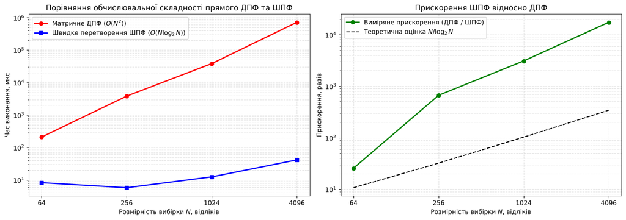

```python
def manual_dft(x_seq, chunk=512):
    """
    Пряме ДПФ через матричне множення X = W_N * x, W_N[m, n] = exp(-j 2 pi m n / N).
    Матриця обчислюється блоками по chunk рядків (економія пам'яті при великих N).
    Показник береться за модулем N, (m*n) mod N, завдяки періодичності W_N; це усуває втрату
    точності при великих аргументах експоненти.
    """
    x_seq = np.asarray(x_seq, dtype=complex)
    N_ = len(x_seq)
    n = np.arange(N_)
    X = np.empty(N_, dtype=complex)
    for r in range(0, N_, chunk):
        m = np.arange(r, min(r + chunk, N_)).reshape(-1, 1)
        W_block = np.exp(-2j * np.pi * ((m * n) % N_) / N_)
        X[r:r + chunk] = W_block @ x_seq
    return X

def best_time_us(f, number, repeat):
    """Мінімальний із repeat вимірів середнього часу виклику, мкс."""
    return min(timeit.repeat(f, number=number, repeat=repeat)) / number * 1e6

N_sizes = [64, 256, 1024, 4096]
n_dft = {64: 100, 256: 10, 1024: 2, 4096: 1}          # кількість викликів у серії
n_fft = {64: 5000, 256: 5000, 1024: 2000, 4096: 500}
time_dft, time_fft, max_err, speedup, speedup_theory = [], [], [], [], []

rng_b = np.random.default_rng(10)
lines = ["=" * 88,
         "ПОРІВНЯННЯ МАТРИЧНОГО ДПФ ТА БІБЛІОТЕЧНОГО АЛГОРИТМУ ШПФ (FFT)",
         "=" * 88,
         f"{'N':>6} | {'Час ДПФ, мкс':>14} | {'Час ШПФ, мкс':>14} | {'Прискорення':>11} | {'N/log2(N)':>9} | {'Макс. похибка':>13}",
         "-" * 88]
for N_val in N_sizes:
    vec = rng_b.standard_normal(N_val) + 1j * rng_b.standard_normal(N_val)
    t_d = best_time_us(lambda: manual_dft(vec), n_dft[N_val], 3 if N_val < 4096 else 2)
    t_f = best_time_us(lambda: np.fft.fft(vec), n_fft[N_val], 5)
    err = float(np.max(np.abs(manual_dft(vec) - np.fft.fft(vec))))
    time_dft.append(t_d); time_fft.append(t_f); max_err.append(err)
    speedup.append(t_d / t_f); speedup_theory.append(N_val / np.log2(N_val))
    lines.append(f"{N_val:6d} | {t_d:14.1f} | {t_f:14.2f} | {t_d / t_f:10.0f}x | {speedup_theory[-1]:9.1f} | {err:13.2e}")
lines.append("=" * 88)
print("\n".join(lines))

slope_dft = np.polyfit(np.log(N_sizes), np.log(time_dft), 1)[0]
slope_fft = np.polyfit(np.log(N_sizes), np.log(time_fft), 1)[0]
print(f"Нахил log-log: ДПФ = {slope_dft:.2f} (теорія: 2); ШПФ = {slope_fft:.2f} (теорія: ≈1; на малих N домінують сталі накладні витрати виклику)")
assert max(max_err) < 1e-9

fig, axes = plt.subplots(1, 2, figsize=(14, 5))
ax = axes[0]
ax.plot(N_sizes, time_dft, 'ro-', lw=2, label=r'Матричне ДПФ ($O(N^2)$)')
ax.plot(N_sizes, time_fft, 'bs-', lw=2, label=r'Швидке перетворення ШПФ ($O(N\log_2 N)$)')
ax.set_xscale('log', base=2); ax.set_yscale('log')
ax.set_xticks(N_sizes); ax.set_xticklabels([str(v) for v in N_sizes])
ax.set_title("Порівняння обчислювальної складності прямого ДПФ та ШПФ")
ax.set_xlabel(r"Розмірність вибірки $N$, відліків"); ax.set_ylabel("Час виконання, мкс")
ax.grid(True, which="both"); ax.legend()

ax = axes[1]
ax.plot(N_sizes, speedup, 'go-', lw=2, label='Виміряне прискорення (ДПФ / ШПФ)')
ax.plot(N_sizes, speedup_theory, 'k--', lw=1.5, label=r'Теоретична оцінка $N/\log_2 N$')
ax.set_xscale('log', base=2); ax.set_yscale('log')
ax.set_xticks(N_sizes); ax.set_xticklabels([str(v) for v in N_sizes])
ax.set_title("Прискорення ШПФ відносно ДПФ")
ax.set_xlabel(r"Розмірність вибірки $N$, відліків"); ax.set_ylabel("Прискорення, разів")
ax.grid(True, which="both"); ax.legend()
plt.tight_layout()
plt.savefig("figures/dft_vs_fft_benchmark.png", dpi=200)
plt.show()
```

## 4. Амплітудний та фазовий спектри сигналу

Синтезуємо $s[n]$ з шумом ($N=256$) і розраховуємо односторонні спектри через ШПФ. Фаза значущих компонент виводиться лише для бінів з амплітудою не менше $0.03$ В (приблизно у 7 разів вище середнього шумового рівня одного біна), решта маскується нулем. Оскільки $f_1$ не кратна $\Delta f$, її пік «розмазується» між сусідніми бінами, амплітуда на найближчому біні 43 занижується (втрати від некратності, scalloping loss), а фаза відліку зсувається на $\pi\varepsilon\frac{N-1}{N}$, де $\varepsilon=m_1-43=-0.333$. Гармоніка $f_2$ лежить точно в біні 48, але з прямокутним вікном накладається на хвіст витоку $f_1$.

```
Шум (без гармонік): середня амплітуда біна = 4.42 мВ; теорія 2σ/√N·√(π)/2 = 4.43 мВ

      f_ист, Гц  бін k   f_k, Гц  |Δf|, Гц   A_k, В  A_ист, В  Φ_k, рад Φ_когер., рад
f1        200.0     43   201.562     1.562   2.4794     3.000    -2.084        -1.047
f2        225.0     48   225.000     0.000   0.1469     0.100    -1.263         0.000

Фаза f1 при некратній частоті (ε = -0.333 біна): теорія Φ = Φ_когер. + π·ε·(N-1)/N = -2.090 рад; виміряна -2.084 рад
Втрати від некратності для f1: 2.479 В замість 3.0 В (-1.66 дБ); теорія |sinc(-0.333)|·A1 = 2.481 В
Амплітуда в біні f2 = 0.147 В замість 0.1 В (+47 %): прямокутне вікно, накладання витоку f1
Максимум спектра в околі f2 (±3 біни) 'наосліп': бін 45 (210.94 Гц, 0.344 В) - це хвіст витоку f1, а не f2
```

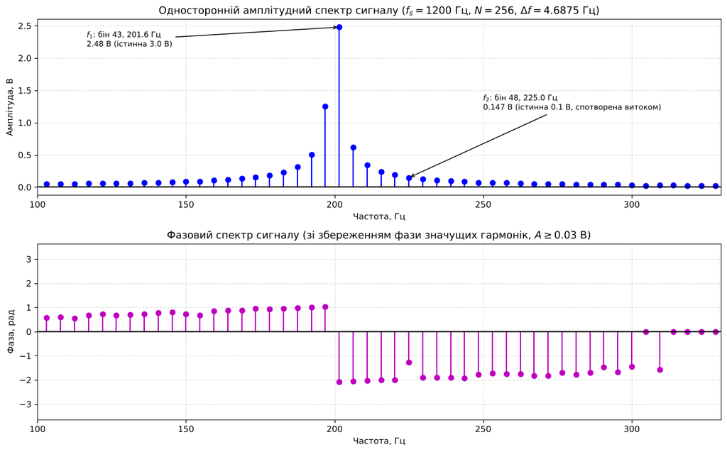

```python
s_total = make_signal(N)
s_pure = make_signal(N, with_noise=False)

X_pos, amp = amplitude_spectrum(s_total)
f_pos = np.arange(N // 2) * df
phase = np.angle(X_pos)
phase_plot = np.where(amp >= 0.03, phase, 0.0)

# Піки: f1 - найбільший відлік поблизу біна 43; f2 - номінальний бін 48 (f2/Δf = 48 - ціле)
k1_nom, k2_nom = int(round(m1)), int(round(m2))
k1 = k1_nom - 3 + int(np.argmax(amp[k1_nom - 3:k1_nom + 4]))
k2 = k2_nom
k2_blind = k2_nom - 3 + int(np.argmax(amp[k2_nom - 3:k2_nom + 4]))     # максимум "наосліп" поблизу f2
phi1_exp = float(np.angle(np.exp(1j * (phi1 - np.pi / 2))))            # sin -> cos зі зсувом -pi/2
phi2_exp = float(np.angle(np.exp(1j * phi2)))
eps1 = m1 - k1                                                         # зсув f1 відносно біна, у бінах
phi1_theory = float(np.angle(np.exp(1j * (phi1_exp + np.pi * eps1 * (N - 1) / N))))

# Контроль шуму: спектр реалізації без гармонік порівнюється з теорією
_, amp_noise = amplitude_spectrum(make_signal(N, with_f1=False, with_f2=False))
noise_theory = 2 * sigma_noise / np.sqrt(N) * np.sqrt(np.pi) / 2
print(f"Шум (без гармонік): середня амплітуда біна = {np.mean(amp_noise[1:]) * 1e3:.2f} мВ; теорія 2σ/√N·√(π)/2 = {noise_theory * 1e3:.2f} мВ")

print(f"\n{'':<5}{'f_ист, Гц':>10}{'бін k':>7}{'f_k, Гц':>10}{'|Δf|, Гц':>10}{'A_k, В':>9}{'A_ист, В':>10}{'Φ_k, рад':>10}{'Φ_когер., рад':>14}")
for name, kk, ft, At, pe in [("f1", k1, f1, A1, phi1_exp), ("f2", k2, f2, A2, phi2_exp)]:
    print(f"{name:<5}{ft:10.1f}{kk:7d}{kk * df:10.3f}{abs(kk * df - ft):10.3f}{amp[kk]:9.4f}{At:10.3f}{phase[kk]:10.3f}{pe:14.3f}")
print(f"\nФаза f1 при некратній частоті (ε = {eps1:.3f} біна): теорія Φ = Φ_когер. + π·ε·(N-1)/N = {phi1_theory:.3f} рад; виміряна {phase[k1]:.3f} рад")
scallop_db = 20 * np.log10(amp[k1] / A1)
print(f"Втрати від некратності для f1: {amp[k1]:.3f} В замість {A1} В ({scallop_db:.2f} дБ); "
      f"теорія |sinc({eps1:.3f})|·A1 = {A1 * abs(np.sinc(eps1)):.3f} В")
print(f"Амплітуда в біні f2 = {amp[k2]:.3f} В замість {A2} В (+{100 * (amp[k2] - A2) / A2:.0f} %): прямокутне вікно, накладання витоку f1")
print(f"Максимум спектра в околі f2 (±3 біни) 'наосліп': бін {k2_blind} ({k2_blind * df:.2f} Гц, {amp[k2_blind]:.3f} В) - це хвіст витоку f1, а не f2")

fig, axes = plt.subplots(2, 1, figsize=(12, 7.5))
ax = axes[0]
ax.stem(f_pos, amp, linefmt='b-', markerfmt='bo', basefmt='k-')
ax.annotate(f"$f_1$: бін {k1}, {k1 * df:.1f} Гц\n{amp[k1]:.2f} В (істинна {A1} В)", xy=(k1 * df, amp[k1]),
            xytext=(k1 * df - 85, amp[k1] - 0.3), fontsize=9, arrowprops=dict(arrowstyle='->'))
ax.annotate(f"$f_2$: бін {k2}, {k2 * df:.1f} Гц\n{amp[k2]:.3f} В (істинна {A2} В, спотворена витоком)", xy=(k2 * df, amp[k2]),
            xytext=(k2 * df + 25, 1.2), fontsize=9, arrowprops=dict(arrowstyle='->'))
ax.set_title(f"Односторонній амплітудний спектр сигналу ($f_s={int(fs)}$ Гц, $N={N}$, $\\Delta f={df}$ Гц)")
ax.set_xlabel("Частота, Гц"); ax.set_ylabel("Амплітуда, В")
ax.set_xlim([100, 330]); ax.grid(True)

ax = axes[1]
ax.stem(f_pos, phase_plot, linefmt='m-', markerfmt='mo', basefmt='k-')
ax.set_title("Фазовий спектр сигналу (зі збереженням фази значущих гармонік, $A \\geq 0.03$ В)")
ax.set_xlabel("Частота, Гц"); ax.set_ylabel("Фаза, рад")
ax.set_xlim([100, 330]); ax.set_ylim([-np.pi - 0.5, np.pi + 0.5]); ax.grid(True)
plt.tight_layout()
plt.savefig("figures/harmonic_spectrum.png", dpi=200)
plt.show()
```

## 5. Дослідження витоку спектра при зміні довжини вікна $N$

Порівнюємо чисту гармоніку $f_1$ ($A_1=3$ В) при двох довжинах вікна: $N=240$ (рівно 40 періодів, $m_1=40$) і $N=256$ (42,667 періоду). Рівень спектра на правому графіку подано відносно істинної амплітуди $A_1$ (дБ), тому втрати амплітуди від некратності також видно. Для порогу $-120$ дБ виконується відсікання (числовий нуль).

Для сигналу з шумом при $N=240$ обидві гармоніки когерентні, і амплітуди та фази відновлюються майже точно.

```
                          N  періодів  бін піку  A_пік, В  втрати, дБ   потужн. поза ±1 бін
кратно                  240    40.000        40    3.0000        0.00              0.00e+00
некратно                256    42.667        43    2.4752       -1.67              1.03e-01

Витік f1 на біні f2 (відстань 5.33 біна, прямокутне вікно): теорія (ядро Дирихле) = 0.1552 В (±0.0113 В від дзеркальної компоненти); чисельно = 0.1498 В; амплітуда самої f2 = 0.1 В

Когерентний випадок N = 240 (сигнал із шумом):
  f1: бін 40, A = 3.0062 В (істинна 3.0), Φ = -1.0456 рад (очік. -1.0472)
  f2: бін 45, A = 0.1014 В (істинна 0.1), Φ = -0.0130 рад (очік. 0.0000)
```

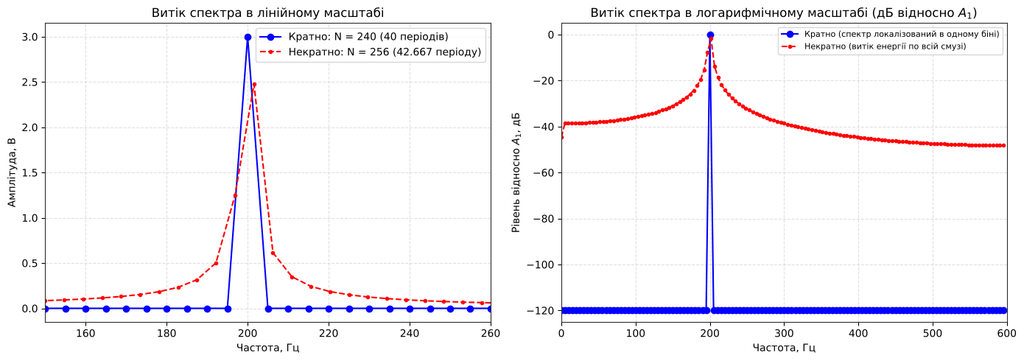

```python
N_a, N_b = N_coh, N                                       # 240 (кратно), 256 (некратно)
x_a = make_signal(N_a, with_noise=False, with_f2=False)
x_b = make_signal(N_b, with_noise=False, with_f2=False)
Xa, amp_a = amplitude_spectrum(x_a)
Xb, amp_b = amplitude_spectrum(x_b)
f_a = np.arange(N_a // 2) * fs / N_a
f_b = np.arange(N_b // 2) * fs / N_b

def power_outside(amp_, k_peak, half_width=1):
    """Частка потужності спектра (без постійної складової) поза бінами k_peak ± half_width."""
    p = amp_[1:] ** 2
    inside = np.sum(amp_[k_peak - half_width:k_peak + half_width + 1] ** 2)
    return 1.0 - inside / np.sum(p)

ka, kb = int(np.argmax(amp_a)), int(np.argmax(amp_b))
print(f"{'':<22}{'N':>5}{'періодів':>10}{'бін піку':>10}{'A_пік, В':>10}{'втрати, дБ':>12}{'потужн. поза ±1 бін':>22}")
for lab, Nn, Nper, kk, am in [("кратно", N_a, f1 * N_a / fs, ka, amp_a), ("некратно", N_b, f1 * N_b / fs, kb, amp_b)]:
    print(f"{lab:<22}{Nn:5d}{Nper:10.3f}{kk:10d}{am[kk]:10.4f}{20 * np.log10(am[kk] / A1):12.2f}{power_outside(am, kk):22.2e}")

assert np.isclose(amp_a[ka], A1, atol=1e-9) and power_outside(amp_a, ka) < 1e-20
# Дирихле: теоретичний рівень витоку на відстані delta бінів від піку (прямокутне вікно)
delta = (f2 - f1) / df
dirichlet = lambda d: abs(np.sin(np.pi * d) / (N * np.sin(np.pi * d / N)))
leak_theory = A1 * dirichlet(delta)                  # внесок f1
leak_image = A1 * dirichlet((f2 + f1) / df)          # поправка від дзеркальної компоненти -f1
assert abs(amp_b[k2_nom] - leak_theory) <= leak_image + 1e-9
print(f"\nВитік f1 на біні f2 (відстань {delta:.2f} біна, прямокутне вікно): теорія (ядро Дирихле) = {leak_theory:.4f} В "
      f"(±{leak_image:.4f} В від дзеркальної компоненти); чисельно = {amp_b[k2_nom]:.4f} В; амплітуда самої f2 = {A2} В")

# Когерентний випадок N = 240 з шумом: точність відновлення амплітуд та фаз
x_c = make_signal(N_coh)
Xc, amp_c = amplitude_spectrum(x_c)
kc1, kc2 = int(round(f1 / df_c)), int(round(f2 / df_c))
print(f"\nКогерентний випадок N = {N_coh} (сигнал із шумом):")
print(f"  f1: бін {kc1}, A = {amp_c[kc1]:.4f} В (істинна {A1}), Φ = {np.angle(Xc[kc1]):.4f} рад (очік. {phi1_exp:.4f})")
print(f"  f2: бін {kc2}, A = {amp_c[kc2]:.4f} В (істинна {A2}), Φ = {np.angle(Xc[kc2]):.4f} рад (очік. {phi2_exp:.4f})")

floor = -120.0
db = lambda a: np.maximum(20 * np.log10(np.maximum(a, 1e-12) / A1), floor)

fig, axes = plt.subplots(1, 2, figsize=(14, 5))
ax = axes[0]
ax.plot(f_a, amp_a, 'bo-', lw=1.5, label=f'Кратно: N = {N_a} (40 періодів)')
ax.plot(f_b, amp_b, 'r.--', lw=1.5, label=f'Некратно: N = {N_b} (42.667 періоду)')
ax.set_title("Витік спектра в лінійному масштабі")
ax.set_xlabel("Частота, Гц"); ax.set_ylabel("Амплітуда, В")
ax.set_xlim([150, 260]); ax.grid(True); ax.legend()

ax = axes[1]
ax.plot(f_a, db(amp_a), 'bo-', lw=1.5, label='Кратно (спектр локалізований в одному біні)')
ax.plot(f_b, db(amp_b), 'r.--', lw=1.5, label='Некратно (витік енергії по всій смузі)')
ax.set_title("Витік спектра в логарифмічному масштабі (дБ відносно $A_1$)")
ax.set_xlabel("Частота, Гц"); ax.set_ylabel("Рівень відносно $A_1$, дБ")
ax.set_xlim([0, 600]); ax.set_ylim([-125, 5]); ax.grid(True); ax.legend(loc='upper right', fontsize=8)
plt.tight_layout()
plt.savefig("figures/spectral_leakage.png", dpi=200)
plt.show()
```

## 6. Віконні функції та виявлення слабкої гармоніки $f_2$ на фоні потужної $f_1$

Порівнюються прямокутне вікно та вікна Ханна, Хеммінга, Блекмана ($N=256$). Для кількісної оцінки використовується бін $m_2=48$, у якому лежить $f_2$:

- $A_w[48]$ — амплітуда в біні $f_2$ у спектрі повного сигналу та її відхилення від істинних $A_2=0.1$ В;
- **витік $f_1$** на біні 48 — окремий розрахунок для сигналу, що містить лише $f_1$ (без шуму і $f_2$); відношення «витік / $A_2$» — найгірше можливе спотворення амплітуди $f_2$ витоком (коли фази збігаються);
- **пік $f_2$ є локальним максимумом** — бін 48 вищий за сусідні біни 47 і 49 (необхідна умова виявлення гармоніки пошуком піків);
- шумова підлога — медіана амплітуд у смузі 350–590 Гц, де гармонік немає (шум плюс далекий витік $f_1$).

```
Вікно           CG  A(f1), В  A(f2), В похибка A2 витік f1, В  витік/A2  шум, дБВ f2/шум, дБ  пік f2  макс.±3б, Гц
Прямокутне  1.0000     2.479    0.1469      46.9%      0.1498    149.8%     -36.2       19.6      ні        210.94
Ханна       0.4980     2.797    0.1051       5.1%      0.0055      5.5%     -45.7       26.1     так        225.00
Хеммінга    0.5382     2.750    0.0969      -3.1%      0.0176     17.6%     -45.9       25.7     так        225.00
Блекмана    0.4184     2.842    0.1036       3.6%      0.0018      1.8%     -45.5       25.8     так        225.00
```

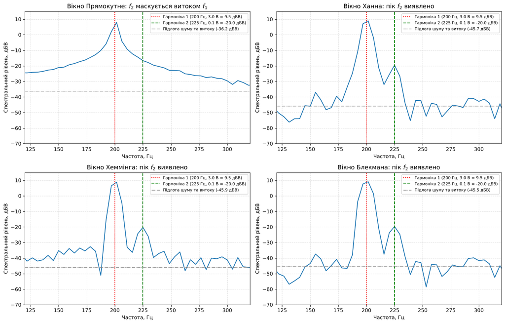

```python
win_dict = {
    'Прямокутне': np.ones(N),
    'Ханна': windows.hann(N),
    'Хеммінга': windows.hamming(N),
    'Блекмана': windows.blackman(N),
}
s_f1_only = make_signal(N, with_noise=False, with_f2=False)
dBV = lambda a: 20 * np.log10(np.maximum(a, 1e-6))
band = slice(75, 126)                       # ≈ 350–590 Гц: смуга без сигналів

rows = {}
lines = [f"{'Вікно':<11}{'CG':>7}{'A(f1), В':>10}{'A(f2), В':>10}{'похибка A2':>11}{'витік f1, В':>12}{'витік/A2':>10}{'шум, дБВ':>10}{'f2/шум, дБ':>11}{'пік f2':>8}{'макс.±3б, Гц':>14}"]
for name, w in win_dict.items():
    _, amp_w = amplitude_spectrum(s_total, w)
    _, amp_lk = amplitude_spectrum(s_f1_only, w)
    cg = float(np.sum(w) / N)
    a_f1 = float(amp_w[k1_nom - 3:k1_nom + 4].max())
    a_f2 = float(amp_w[k2_nom])
    leak = float(amp_lk[k2_nom])
    floor_v = float(np.median(amp_w[band]))
    local_max = bool(amp_w[k2_nom] > amp_w[k2_nom - 1] and amp_w[k2_nom] > amp_w[k2_nom + 1])
    k_blind = k2_nom - 3 + int(np.argmax(amp_w[k2_nom - 3:k2_nom + 4]))
    rows[name] = dict(cg=cg, a_f1=a_f1, a_f2=a_f2, err_a2_pct=100 * (a_f2 - A2) / A2, leak_f1_at_f2=leak,
                      leak_pct_of_a2=100 * leak / A2, noise_floor_dbv=float(dBV(floor_v)),
                      f2_over_noise_db=float(dBV(a_f2) - dBV(floor_v)), f2_peak_is_local_max=local_max,
                      f2_blind_peak_hz=float(k_blind * df), level_f2_dbv=float(dBV(a_f2)))
    r = rows[name]
    lines.append(f"{name:<11}{cg:7.4f}{a_f1:10.3f}{a_f2:10.4f}{r['err_a2_pct']:10.1f}%{leak:12.4f}{r['leak_pct_of_a2']:9.1f}%"
                 f"{r['noise_floor_dbv']:10.1f}{r['f2_over_noise_db']:11.1f}{'так' if local_max else 'ні':>8}{r['f2_blind_peak_hz']:14.2f}")
print("\n".join(lines))

fig, axes = plt.subplots(2, 2, figsize=(14, 9))
for ax, (name, w) in zip(axes.flatten(), win_dict.items()):
    _, amp_w = amplitude_spectrum(s_total, w)
    ax.plot(f_pos, dBV(amp_w), color='#1f77b4', lw=1.5)
    ax.axvline(f1, color='r', linestyle=':', label=f'Гармоніка 1 ({f1:.0f} Гц, {A1} В = {dBV(A1):.1f} дБВ)')
    ax.axvline(f2, color='g', linestyle='--', label=f'Гармоніка 2 ({f2:.0f} Гц, {A2} В = {dBV(A2):.1f} дБВ)')
    ax.axhline(rows[name]['noise_floor_dbv'], color='gray', linestyle='-.', lw=1, label=f"Підлога шуму та витоку ({rows[name]['noise_floor_dbv']:.1f} дБВ)")
    ax.set_title(f"Вікно {name}: " + ("пік $f_2$ виявлено" if rows[name]['f2_peak_is_local_max'] else "$f_2$ маскується витоком $f_1$"))
    ax.set_xlabel("Частота, Гц"); ax.set_ylabel("Спектральний рівень, дБВ")
    ax.set_xlim([120, 320]); ax.set_ylim([-70, 15]); ax.grid(True)
    ax.legend(loc='upper right', fontsize=8)
plt.tight_layout()
plt.savefig("figures/window_functions_comp.png", dpi=200)
plt.show()
```

### Характеристики вікон: головна пелюстка та бічні пелюстки

Для підтвердження табличних даних характеристики вікон ($N=256$) обчислено чисельно за ШПФ з нульовим доповненням до $32N$ точок: ширина головної пелюстки за нулями, рівень найбільшої бічної пелюстки та еквівалентна шумова смуга $\mathrm{ENBW}=N\sum w^2/(\sum w)^2$.

```
Вікно           CG  ENBW, біни  ширина гол. пел., біни  макс. бічна, дБ
Прямокутне   1.000       1.000                    2.00            -13.3
Ханна        0.498       1.506                    4.00            -31.5
Хеммінга     0.538       1.367                    4.06            -42.7
Блекмана     0.418       1.734                    6.12            -58.1
```

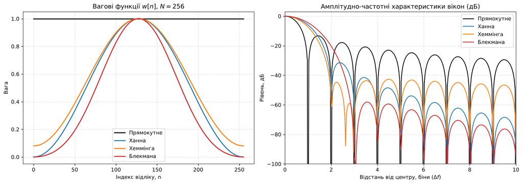

```python
NFFT = 32 * N
win_props = {}
fig, axes = plt.subplots(1, 2, figsize=(14, 5))
n_axis = np.arange(N)
colors = {'Прямокутне': 'k', 'Ханна': 'C0', 'Хеммінга': 'C1', 'Блекмана': 'C3'}

print(f"{'Вікно':<11}{'CG':>7}{'ENBW, біни':>12}{'ширина гол. пел., біни':>24}{'макс. бічна, дБ':>17}")
for name, w in win_dict.items():
    H = np.abs(np.fft.rfft(w, NFFT))
    H_db = 20 * np.log10(np.maximum(H / H.max(), 1e-12))
    bins = np.arange(len(H)) * N / NFFT
    i_null = int(np.argmax(np.diff(H) > 0))                 # перший нуль головної пелюстки
    width = 2 * bins[i_null]
    sidelobe = float(H_db[i_null:].max())
    enbw = float(N * np.sum(w ** 2) / np.sum(w) ** 2)
    win_props[name] = dict(cg=float(np.sum(w) / N), enbw=enbw, mainlobe_width_bins=float(width), sidelobe_db=sidelobe)
    print(f"{name:<11}{np.sum(w) / N:7.3f}{enbw:12.3f}{width:24.2f}{sidelobe:17.1f}")
    axes[0].plot(n_axis, w, color=colors[name], lw=1.8, label=name)
    axes[1].plot(bins, H_db, color=colors[name], lw=1.4, label=name)

axes[0].set_title("Вагові функції $w[n]$, $N=256$")
axes[0].set_xlabel("Індекс відліку, n"); axes[0].set_ylabel("Вага"); axes[0].grid(True); axes[0].legend()
axes[1].set_title("Амплітудно-частотні характеристики вікон (дБ)")
axes[1].set_xlabel("Відстань від центру, біни ($\\Delta f$)"); axes[1].set_ylabel("Рівень, дБ")
axes[1].set_xlim([0, 10]); axes[1].set_ylim([-100, 3]); axes[1].grid(True); axes[1].legend()
plt.tight_layout()
plt.savefig("figures/window_characteristics.png", dpi=200)
plt.show()
```

## 7. Експорт результатів

```python
# Спектри (односторонні, N = 256) для чотирьох вікон
cols, header = [f_pos], ["f_Hz"]
for name, w in win_dict.items():
    _, a_w = amplitude_spectrum(s_total, w)
    cols.append(a_w); header.append("amp_" + {"Прямокутне": "rect", "Ханна": "hann", "Хеммінга": "hamming", "Блекмана": "blackman"}[name])
cols.append(phase_plot); header.append("phase_rect_rad")
np.savetxt("data/spectrum.csv", np.column_stack(cols), delimiter=",", header=",".join(header), comments="")

np.savetxt("data/benchmark.csv",
           np.column_stack([N_sizes, time_dft, time_fft, speedup, max_err]),
           delimiter=",", header="N,t_dft_us,t_fft_us,speedup,max_error", comments="")

results = dict(
    variant=2, fs=fs, N=N, df=df, N_coherent=N_coh,
    params=dict(A1=A1, f1=f1, phi1=phi1, A2=A2, f2=f2, phi2=phi2, sigma_noise=sigma_noise),
    m1=m1, m2=m2, ratio_A1_A2_db=float(ratio_db),
    benchmark=dict(N=N_sizes, t_dft_us=time_dft, t_fft_us=time_fft, speedup=speedup,
                   speedup_theory=speedup_theory, max_error=max_err,
                   slope_dft=float(slope_dft), slope_fft=float(slope_fft)),
    peaks_rect_N256=dict(f1=dict(bin=k1, f_hz=k1 * df, amp=float(amp[k1]), phase=float(phase[k1]), phase_theory=phi1_theory),
                         f2=dict(bin=k2, f_hz=k2 * df, amp=float(amp[k2]), phase=float(phase[k2])),
                         f2_blind_peak=dict(bin=k2_blind, f_hz=k2_blind * df, amp=float(amp[k2_blind]))),
    scalloping_loss_db=float(scallop_db),
    leakage=dict(N_coherent_peak=float(amp_a[ka]), N_noncoherent_peak=float(amp_b[kb]),
                 power_outside_coherent=float(power_outside(amp_a, ka)),
                 power_outside_noncoherent=float(power_outside(amp_b, kb)),
                 leak_f1_at_f2_bin_theory=float(leak_theory), leak_f1_at_f2_bin_image_term=float(leak_image),
                 leak_f1_at_f2_bin_numeric=float(amp_b[k2_nom])),
    coherent_N240=dict(f1=dict(amp=float(amp_c[kc1]), phase=float(np.angle(Xc[kc1]))),
                       f2=dict(amp=float(amp_c[kc2]), phase=float(np.angle(Xc[kc2])))),
    windows=rows, window_properties=win_props,
)
with open("data/results.json", "w", encoding="utf-8") as f:
    json.dump(results, f, ensure_ascii=False, indent=1)
print("Готово: figures/, data/")
```

```
Готово: figures/, data/
```

## Висновки

1. **ДПФ та ШПФ.** Матричне ДПФ має складність $O(N^2)$: у log–log масштабі нахил часової залежності ≈ 2, а для $N=4096$ розрахунок триває сотні мілісекунд проти десятків мікросекунд у `np.fft.fft`. Виміряне прискорення (порядку $10^4$ для $N=4096$) суттєво перевищує теоретичну оцінку $N/\log_2N\approx341$, бо в час ДПФ входить обчислення $N^2$ експонент, а ШПФ реалізовано оптимізованим кодом; тенденція зростання прискорення з $N$ збігається з теорією. Результати обох алгоритмів збігаються до $\sim10^{-13}$ (похибка округлення). Для точності показник матриці береться за модулем $N$, $(m\,n)\bmod N$, що використовує періодичність $W_N$.
2. **Спектри при $N=256$, $\Delta f=4.6875$ Гц.** Частота $f_1=200$ Гц некратна сітці ($m_1=42.667$): пік припадає на бін 43 ($201.56$ Гц, похибка частоти $1.56$ Гц $=0.33\,\Delta f$), амплітуда занижена до $2.479$ В замість $3.0$ В ($-1.66$ дБ, теорія $|\mathrm{sinc}(\varepsilon)|A_1=2.481$ В), а фаза ($-2.084$ рад) відрізняється від когерентної ($-1.047$ рад) на $\pi\varepsilon(N-1)/N$; теоретичне значення $-2.090$ рад. Частота $f_2=225$ Гц кратна сітці (бін 48), проте з прямокутним вікном амплітуда в цьому біні $0.147$ В замість $0.1$ В (+47 %), а фаза $-1.263$ рад замість $0$: витік $f_1$ ($0.150$ В; ядро Дирихле дає $0.155\pm0.011$ В) перевищує саму $f_2$. Пошук максимуму «наосліп» поблизу $f_2$ знаходить бін 45, тобто хвіст витоку $f_1$, а не гармоніку $f_2$. Середній рівень шуму одного біна $4.42$ мВ збігається з теорією ($4.43$ мВ).
3. **Витік спектра.** При $N=240$ ($f_1$ вкладає рівно 40 періодів) спектр чистої гармоніки локалізований в одному біні ($A=3.0000$ В, потужність поза $\pm1$ біном дорівнює нулю). При $N=256$ (42.667 періоду) амплітуда падає до $2.475$ В, близько 10 % потужності виходить за межі трьох бінів навколо піку, а на відстані понад 100 Гц від піку рівень витоку становить $-36\ldots-48$ дБ відносно $A_1$ до самої частоти Найквіста (вище за рівень шуму, $\approx-57$ дБ). При $N=240$ (кратному $\mathrm{НСК}(6,16)=48$) обидві гармоніки когерентні, і навіть із шумом відновлюються $A_1=3.006$ В, $A_2=0.101$ В, фази $-1.046$ та $-0.013$ рад (істинні $-1.047$ та $0$): якщо $N$ можна підібрати кратним періодам, вікна не потрібні.
4. **Вікна та виявлення $f_2$** (відстань від $f_1$ — 5.33 біна, співвідношення $A_1/A_2=29.5$ дБ). *Прямокутне вікно:* $f_2$ маскується — бін 48 не є локальним максимумом, витік складає 150 % від $A_2$, підлога спектра ($-36.2$ дБВ) визначається витоком, а не шумом. *Ханна:* пік виявлено, витік $5.5$ % від $A_2$, $A_2=0.105$ В (+5 %). *Хеммінга:* пік виявлено, але попри нижчу першу бічну пелюстку ($-42.7$ дБ проти $-31.5$ дБ у Ханна) витік на відстані 5.33 біна втричі більший ($17.6$ % від $A_2$), бо бічні пелюстки Хеммінга спадають лише на $-6$ дБ/октава проти $-18$ дБ/октава у Ханна та Блекмана; виміряна похибка $-3$ % є лише результатом сприятливої фази, гарантована точність не краща за $\pm18$ %. *Блекмана:* найменший витік ($1.8$ % від $A_2$), $A_2=0.104$ В (+3.6 %). Залишкові відхилення $3\ldots5$ % для вікон Ханна та Блекмана зумовлені шумом ($\approx4\ldots5$ мВ на бін). Усі три віконні спектри мають підлогу $\approx-45.5\ldots-45.9$ дБВ, а $f_2$ перевищує її приблизно на 26 дБ.
5. **Вибір вікна та компроміс.** Чисельно виміряні характеристики збігаються з теорією: головна пелюстка (за нулями) $2/4/4.06/6.12$ біна, найбільша бічна пелюстка $-13.3/-31.5/-42.7/-58.1$ дБ, коефіцієнт когерентного підсилення $1.000/0.498/0.538/0.418$ для прямокутного/Ханна/Хеммінга/Блекмана; зменшення бічних пелюсток оплачується розширенням головної (ENBW зростає з $1.0$ до $1.73$ біна). Втрати амплітуди $f_1$ від некратності при цьому знижуються з $1.7$ дБ до $0.5\ldots0.8$ дБ. Для виявлення слабкої гармоніки поруч із потужною найкраще підходять вікна Блекмана (максимальне придушення витоку) та Ханна (вужча головна пелюстка за порівнянного результату); оскільки гармоніки розділені на 5.33 біна, а півширина головної пелюстки Блекмана складає лише ≈3.1 біна, її розширення не заважає роздільності. Нормування амплітуди на $\sum w[n]$ (когерентне підсилення) необхідне для коректного відновлення вольтів.

## Контрольні питання:

### 1. У чому полягає математична та алгоритмічна різниця між прямим дискретним перетворенням Фур'є (ДПФ) та алгоритмами швидкого перетворення Фур'є (ШПФ / FFT)?

- **Математично** різниці в результаті немає: ШПФ обчислює абсолютно те саме дискретне перетворення Фур'є, визначене як:

$$X[k] = \sum_{n=0}^{N-1} x[n] W_N^{kn}, \quad \text{де } W_N = e^{-j\frac{2\pi}{N}}$$

Математична різниця полягає у використанні симетрії ($W_N^{k + N/2} = -W_N^k$) та періодичності ($W_N^{k + N} = W_N^k$) поворотних множників для факторизації матриці перетворення.

- **Алгоритмічно**:
- Пряме ДПФ розраховується прямим матрично-векторним множенням «в лоб», що вимагає обчислювальної складності порядка $\mathcal{O}(N^2)$ комплексних множень і додавань.
- ШПФ використовує принцип «розділяй і володарюй» (декомпозицію задачі розміру $N$ на простіші підзадачі меншого розміру), що знижує обчислювальну складність до $\mathcal{O}(N \log_2 N)$.

### 2. Чому алгоритм ШПФ Кулі-Тьюкі за основою 2 вимагає, щоб розмірність послідовності $N$ була цілим степенем двійки ($N = 2^\nu$)?

Алгоритм за основою 2 (radix-2) ґрунтується на багаторазовому рекурсивному розбитті (децимації/проріджуванні) вхідної послідовності довжиною $N$ на дві рівні підпослідовності розміром $N/2$ (наприклад, окремо на відліки з парними та непарними індексами).

Щоб такий поділ навпіл без залишку міг тривати на кожному з $\nu$ каскадів аж до виродження у найпростіші двоточкові перетворення, загальна довжина $N$ обов'язково повинна ділитися на 2 на кожному кроці, тобто бути цілим степенем двійки:

$$N = 2^\nu, \quad \text{де } \nu = \log_2 N \text{ — кількість каскадів обчислення.}$$

### 3. Що являє собою операція «метелик» (butterfly) у графі потоку даних ШПФ з проріджуванням за часом?

Операція «метелик» — це базовий двоточковий обчислювальний модуль у графі потоку даних ШПФ, що об'єднує проміжні результати ДПФ меншого порядку для отримання результатів наступного каскаду.

Для двох комплексних входів $A$ та $B$ і поворотного множника $W_N^r$ операція виконує одне множення, одне додавання та одне віднімання:

$$X = A + B \cdot W_N^r$$

$$Y = A - B \cdot W_N^r$$

Свою назву операція отримала через характерне перехресне розташування ліній зв'язку на схемі сигнального графа, схоже на крила метелика.

### 4. Яка фізична причина виникнення ефекту розтікання (витоку) спектра (spectral leakage), і за якої умови розтікання енергії буде мінімальним або повністю відсутнім?

- **Фізична причина**: ДПФ оперує скінченним відрізком сигналу довжиною $T_w = N T_s$, що математично еквівалентно множенню нескінченного сигналу на прямокутне вікно спостереження. У частотній області це операція згортки спектра сигналу зі спектром вікна ($\mathrm{sinc}$-подібною функцією Діріхле). Крім того, ДПФ неявно розглядає вирізаний фрагмент як нескінченно повторюваний період. Якщо сигнал не є періодичним у межах вікна, на його стиках виникає розрив неперервності (стрибок), що призводить до «розмазування» енергії за межі власної гармоніки на сусідні частоти.
- **Умова відсутності розтікання**: Ефект повністю відсутній, коли на інтервалі спостереження $T_w$ вкладається строго ціле число періодів сигналу $T$:

$$T_w = m \cdot T \quad \iff \quad f_0 = m \cdot \Delta f = m \cdot \frac{f_s}{N}, \quad m \in \mathbb{Z}$$

У цьому випадку частота сигналу точно збігається з одним із базисних дискретних бінів ДПФ, а всі нулі спектральної функції вікна припадають точно на інші біни сітки.

### 5. Яким чином вибір кроку дискретизації за часом $T_s$ та розміру вікна аналізу $N$ впливає на частотну роздільну здатність $\Delta f$ дискретного спектра?

Частотна роздільна здатність (крок між сусідніми спектральними лініями/бінами) визначається співвідношенням:

$$\Delta f = \frac{f_s}{N} = \frac{1}{N T_s} = \frac{1}{T_w}$$

де:

- $f_s = 1/T_s$ — частота дискретизації;
- $T_w = N T_s$ — загальна тривалість інтервалу спостереження.

**Вплив параметрів**:

- Зменшення кроку дискретизації $T_s$ (збільшення $f_s$) за незмінного $N$ розширює смугу Найквіста, але **погіршує** (збільшує) крок $\Delta f$.
- Збільшення розміру вибірки $N$ за постійного $T_s$ пропорційно покращує (зменшує) $\Delta f$.
- Фізична роздільна здатність залежить виключно від **сумарної тривалості сигналу в часі** $T_w$: що довше спостереження, то вища спектральна роздільна здатність.

### 6. Чому прямокутне вікно має найвужчу головну пелюстку, але є непридатним для виявлення слабких сигналів поблизу потужних спектральних піків?

- **Найвужча головна пелюстка**: Прямокутне вікно не знижує амплітуду сигналу по краях ($w[n] = 1$), забезпечуючи максимально можливий ефективний час спостереження, тому ширина його головної пелюстки за нулями мінімальна серед усіх вікон і дорівнює $\Delta f_0 = 2 f_s / N$.
- **Непридатність для слабких сигналів**: Рівень бічних пелюсток прямокутного вікна надзвичайно високий — перша бічна пелюстка пригнічена лише на $-13\text{ дБ}$ відносно головної, а спад бічних пелюсток повільний ($\sim 6\text{ дБ/октаву}$). Якщо поруч із потужним сигналом розташований слабкий, потужні бічні пелюстки першого повністю замаскують головну пелюстку слабкого сигналу, зробивши його виявлення неможливим.

### 7. Чим відрізняються вікна Ханна та Хеммінга за коефіцієнтами розкладу, формою бічних пелюсток та швидкістю їхнього спаду?

Обидва вікна описуються узагальненою формулою косинусного розкладу:

$$w[n] = a_0 - a_1 \cos\left(\frac{2\pi n}{N-1}\right)$$

| Параметр | Вікно Ханна (Hanning) | Вікно Хеммінга (Hamming) |
| --- | --- | --- |
| **Коефіцієнти розкладу** | $a_0 = 0.5, \; a_1 = 0.5$ (спадає строго до $0$ на краях) | $a_0 \approx 0.54, \; a_1 \approx 0.46$ (має «сходинку» на краях: $w[0] = w[N-1] = 0.08$) |
| **Рівень першої бічної пелюстки** | $\approx -31.5\text{ дБ}$ | $\approx -42.5\text{ дБ}$ (оптимізовано для мінімізації першого бічного піка) |
| **Швидкість спаду бічних пелюсток** | **$-18\text{ дБ/октаву}$** ($-60\text{ дБ/декаду}$, асимптотика $\sim 1/f^3$) завдяки плавній неперервності функції та її похідної на краях | **$-6\text{ дБ/октаву}$** ($-20\text{ дБ/декаду}$, асимптотика $\sim 1/f$) через стрибок функції на межах |

Вікно Хеммінга краще пригнічує бічні пелюстки в безпосередній близькості до піка, проте вікно Ханна значно швидше затухає на віддалених частотах.

### 8. Що таке когерентне підсилення вікна ($CG$), і для чого здійснюється нормування амплітудного спектра на величину $\sum_{n=0}^{N-1} w[n]$?

- **Когерентне підсилення вікна (Coherent Gain, $CG$)** — це коефіцієнт передачі віконної функції для постійної складової або когерентного детермінованого гармонійного сигналу, фаза якого узгоджена з базисом Фур'є. Абсолютне значення дорівнює сумі вагових коефіцієнтів вікна:

$$CG = \sum_{n=0}^{N-1} w[n]$$

(або в нормованому вигляді: $CG_{\text{norm}} = \frac{1}{N} \sum_{n=0}^{N-1} w[n]$).

- **Призначення нормування**: Будь-яке вагове вікно (крім прямокутного) згладжує відліки сигналу до країв, що штучно зменшує сумарну енергію та занижує пікові значення в розрахованому спектрі ДПФ. Ділення амплітудного спектра на суму відліків вікна $\sum_{n=0}^{N-1} w[n]$ компенсує втрату амплітуди через зважування та відновлює справжнє фізичне значення пікової амплітуди гармонік у вхідному сигналі.